# 52414 - lab 1

```r
is.character(all.equal(deaths.agg, deaths.agg2))
```

```
## [1] TRUE
```

```r
is.character(all.equal(recovered.agg, recovered.agg2))
```

```
## [1] TRUE
```

```r
#d
# new data-frame of cases, deaths, recovered by 31.3.2020
cases_march <- cases.agg[which(cases.agg$Date == "2020-03-31"),]
deaths_march <- deaths.agg[which(deaths.agg$Date == "2020-03-31"),]
recovered_march <- recovered.agg[which(recovered.agg$Date == "2020-03-31"),]

# create full data-frame of 3 tables - cases, deaths, recovered with sick column
join_corona <- left_join(cases_march,deaths_march,by="Country.Region")
join_corona <- left_join(join_corona, recovered_march)
```

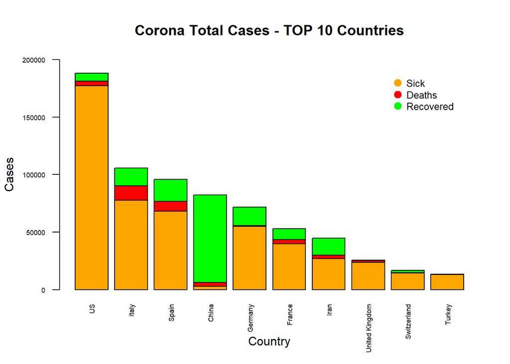

```r
join_corona$sick <- c(join_corona$Value.x-join_corona$Value.y-join_corona$Value)

# create full data-frame of 3 tables - cases, deaths, recovered with sick column
top_join_corona <- head(join_corona[order(join_corona$Value.x , decreasing = TRUE),],10)

# create new table for the bar plot table with type coloumn =sick/deaths/recovered
barp_table <- data.frame(name = rep(c("sick","deaths","recovered"), each = 10), country = rep(top_join_corona$Country.Region,3),values = c(top_join_corona$sick, top_join_corona$Value.y, top_join_corona$Value))

# Create visualization variables for the barplot
colors = c("orange","red","green")
val_mat <- matrix(c(barp_table$values),nrow = 3,ncol = 10,byrow = TRUE)
countries <- as.vector(top_join_corona$Country.Region)
kind <- c( "Sick", "Deaths","Recovered")

# create the bar plot
{barplot(val_mat, main = "Corona Total Cases - TOP 10 Countries", names.arg = countries ,las = 2, xlab = "Country", ylab = "Cases",cex.axis= 0.55, cex.names = 0.55, col = colors,ylim = c(0,200000))
legend("topright", kind , col = colors , bty = "n", pch=20 , pt.cex = 2, cex = 0.8, horiz = FALSE, inset = c(0.05, 0.05))}
```

### 1.d

-The biggest problem is that the 10 shown countries are top only in there confurmed corona cases, it doesnt show the top 10 countries in case of deaths or recovery, it is a lack of information.

### Q2

### Analysis of Daily New Corona Cases and Deaths

20 points

The two datasets (Corona Cases and Deaths) register the value of cases and deaths, respectively, as a cumulative sum for each day. In this question we would like to understand the daily differences between consecutive days.

1. Add a new column named `Diff` to both the `cases.agg` and the `deaths.agg` data-frames. This new column should register the daily `Value` difference for each country. In other words, the `Diff` column shows how many new cases/deaths each country incurs every day. Hint - diff must be per country. (7pts)
2. Find the top 10 instances of country and date combinations with the greatest absolute number of new daily Corona cases and deaths (separately). Print the result in a descriptive format. (5pts)
3. In one figure, plot Italy’s new daily Corona cases AND deaths as a function of Date. Choose the plot type you think that makes the most sense. (3pts)
4. Plot the same graph as in (c), but this time plot the number of new cases on the logarithm scale. What can we learn? (5pts)  
   **Soluton:**

```r
 # a - Add a diff column for cases and deaths data frames
cases.agg <-cases.agg[order(cases.agg$Country.Region, decreasing = FALSE),]
cases.agg <- cases.agg %>%
  group_by(Country.Region) %>%
   mutate(Diff = Value-lag(Value))

deaths.agg <- deaths.agg[order(deaths.agg$Country.Region,decreasing = FALSE),]
deaths.agg <- deaths.agg %>%
  group_by(Country.Region) %>%
  mutate(Diff = Value-lag(Value))

# b - top 10 contries with the greatest absolute number of new daily Corona cases and deaths
top_cases.agg <- head(cases.agg[order(cases.agg$Diff, decreasing = TRUE),],10)
top_deaths.agg <- head(deaths.agg[order(deaths.agg$Diff,decreasing = TRUE),],10)
#  Print the result in a descriptive format
top_cases.agg
```

```
## # A tibble: 10 x 4
## # Groups:   Country.Region [1]
##    Country.Region Date        Value  Diff
##    <fct>          <date>      <int> <int>
##  1 US             2020-04-24 905358 36188
##  2 US             2020-04-09 462780 34126
##  3 US             2020-04-10 496535 33755
##  4 US             2020-04-04 308650 33283
##  5 US             2020-04-18 732197 32491
##  6 US             2020-04-17 699706 32114
##  7 US             2020-04-03 275367 31745
##  8 US             2020-04-08 428654 31533
##  9 US             2020-04-16 667592 31242
## 10 US             2020-04-07 397121 30804
```

```r
top_deaths.agg
```

```
## # A tibble: 10 x 4
## # Groups:   Country.Region [1]
##    Country.Region Date       Value  Diff
##    <fct>          <date>     <int> <int>
##  1 US             2020-04-16 32930  4592
##  2 US             2020-04-17 36787  3857
##  3 US             2020-04-23 49954  3332
##  4 US             2020-04-15 28338  2495
##  5 US             2020-04-21 44444  2350
##  6 US             2020-04-14 25843  2305
##  7 US             2020-04-22 46622  2178
##  8 US             2020-04-10 18595  2051
##  9 US             2020-04-07 12794  2011
## 10 US             2020-04-19 40661  1997
```

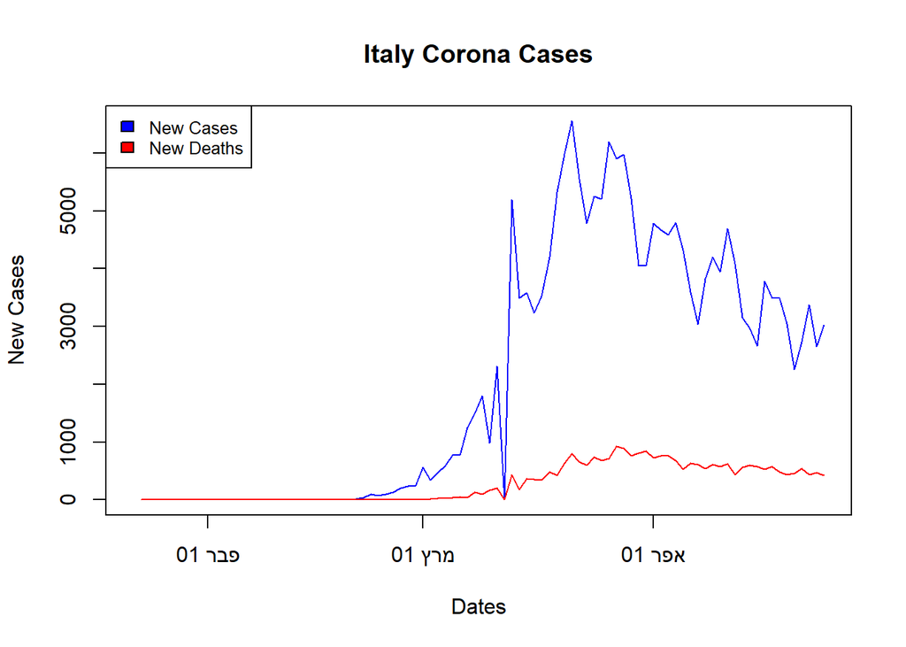

```r
# c - Italy's new daily Corona cases AND deaths
italy_cases <- cases.agg[which(cases.agg$Country.Region=="Italy"),]
italy_deaths <- deaths.agg[which(deaths.agg$Country.Region == "Italy"),]

# Italy's new daily Corona cases AND deaths as a function of Date - plot

{plot(as.numeric(italy_cases$Diff) ~ as.Date(italy_cases$Date),type="l"  ,xlab = "Dates", ylab = "New Cases", main =  "Italy Corona Cases", col = "blue") + lines(as.numeric(italy_deaths$Diff) ~ as.Date(italy_cases$Date),type="l", col = "red")
legend("topleft",c("New Cases","New Deaths"),cex = 0.8, fill = c("blue","red"))}
```

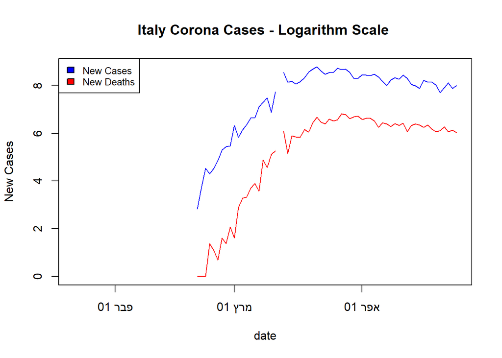

```r
# d Italy's new daily Corona cases AND deaths as a function of Date - logarithm scale
{plot(log(as.numeric(italy_cases$Diff)) ~ as.Date(italy_cases$Date),type="l"  ,xlab = "date", ylab = "New Cases", main =  "Italy Corona Cases - Logarithm Scale ", col = "blue") + lines(log(as.numeric(italy_deaths$Diff)) ~ as.Date(italy_cases$Date),type="l", col = "red")
legend("topleft",c("New Cases","New Deaths"),cex = 0.8, fill = c("blue","red"))}
```

###2.d -The graphs show that the rate of cases has fallen since mid-March. It can be concluded that Italy changed its policy on these dates.

### Q3

### Preparing and Analyzing the World Bank Data

25 points

1. Rename the columns of `eco_data`: `country,S_country,feature,feature_code,Y2018V,Y2019V`. (2pts)
2. Create a new `eco` data-frame whose dimensions are $266 \times 11$. The first column should include the names of the countries in `eco_data.`  
   The rest of the columns should be the features with their respective values in `eco_data` for each country from 2018. Print the head of the new data-frame.(8pts)
3. Select and rename the following columns: `country` as country, `GDP(US currency)` as GDP, `Population ages 65 and above (% of total population)` as pop65, `Population in the largest city (% of urban population)` as pop_city_ratio, `Population, total` as pop_total columns . (2pts)
4. Show a table of the five countries with the highest per capita GDP in 2018.  
   Next (considering all countries), plot the % of population over 65 vs. log of GDP per capita in 2018, after excluding the 10% countries with the lowest GDP per capita. Using `lm` and `abline`, add a regression line to the plot. What is your conclusion? (13 pts)

**Soluton:**

```r
#a
eco_data <- read.csv(url("https://raw.githubusercontent.com/DataScienceHU/DataAnalysisR_2020/master/data/economic_data.csv"))
names(eco_data)[names(eco_data)== "ן..Country.Name"] <- "country"
names(eco_data)[names(eco_data)== "Country.Code"] <- "S_country"
names(eco_data)[names(eco_data)== "Series.Name"] <- "feature"
names(eco_data)[names(eco_data)== "Series.Code"] <- "feature_code"
names(eco_data)[names(eco_data)== "X2018..YR2018."] <- "Y2018V"
names(eco_data)[names(eco_data)== "X2019..YR2019."] <- "Y2019V"

#b - create `eco` data-frame whose dimensions are 264 X 11.
eco_data<- eco_data[-c(2641:2645),]
eco <- dcast(eco_data, country~feature, value.var="Y2018V")
dim(eco)
```

```
## [1] 264  11
```

```r
head(eco,10)
```

```
##                country GDP (constant LCU) GDP (current US$)
## 1          Afghanistan   511432475534.156  19362969582.3643
## 2              Albania      1513259270000   15102500898.238
## 3              Algeria   6123376375970.86   173757952824.25
## 4       American Samoa          608000000         636000000
## 5              Andorra         2002840000  3236543909.34844
## 6               Angola      1552771000000   105750987618.63
## 7  Antigua and Barbuda         3516470000  1610574074.07407
## 8           Arab World                 ..  2774314967156.43
## 9            Argentina       707329642300  519871519807.795
## 10             Armenia      5339485715500  12433089919.0459
##    GDP, PPP (current international $)
## 1                    72672245387.0863
## 2                    38306694289.2319
## 3                    653771569286.319
```

[output cut: 73 more lines]

```r
#c - rename the relevant columns
names(eco)[names(eco)== "GDP (current US$)"] <- "GDP"
names(eco)[names(eco)== "Population ages 65 and above (% of total population)"] <- "pop65"
names(eco)[names(eco)== "Population in the largest city (% of urban population)"] <- "pop_city_ratio"
names(eco)[names(eco)== "Population, total"] <- "pop_total"

#d
# calculate column GDP per Capita and find the top 5 countries according to that
eco$GDP_per_capita <- c(suppressWarnings(as.numeric(eco$GDP ) / as.numeric(eco$pop_total)))
top5 <-head (eco[order(eco$GDP_per_capita , decreasing = TRUE),],5)
top5
```

```
##              country GDP (constant LCU)              GDP
## 163           Monaco   5720647180.37038 7184844192.63456
## 145       Luxembourg        57152595000 70885325883.0941
## 146 Macao SAR, China       429497000000 55084050789.7182
## 234      Switzerland       696139480200 705140354166.312
## 181           Norway      3259053000000 434166615431.909
##     GDP, PPP (current international $)
## 163                                 ..
## 145                   68878323882.4048
## 146                   78254752438.0468
## 234                   579643931032.338
## 181                   348145261704.001
##     Government expenditure on education, total (% of GDP)            pop65
## 163                                                    ..               ..
## 145                                                    .. 14.1831541841472
```

[output cut: 33 more lines]

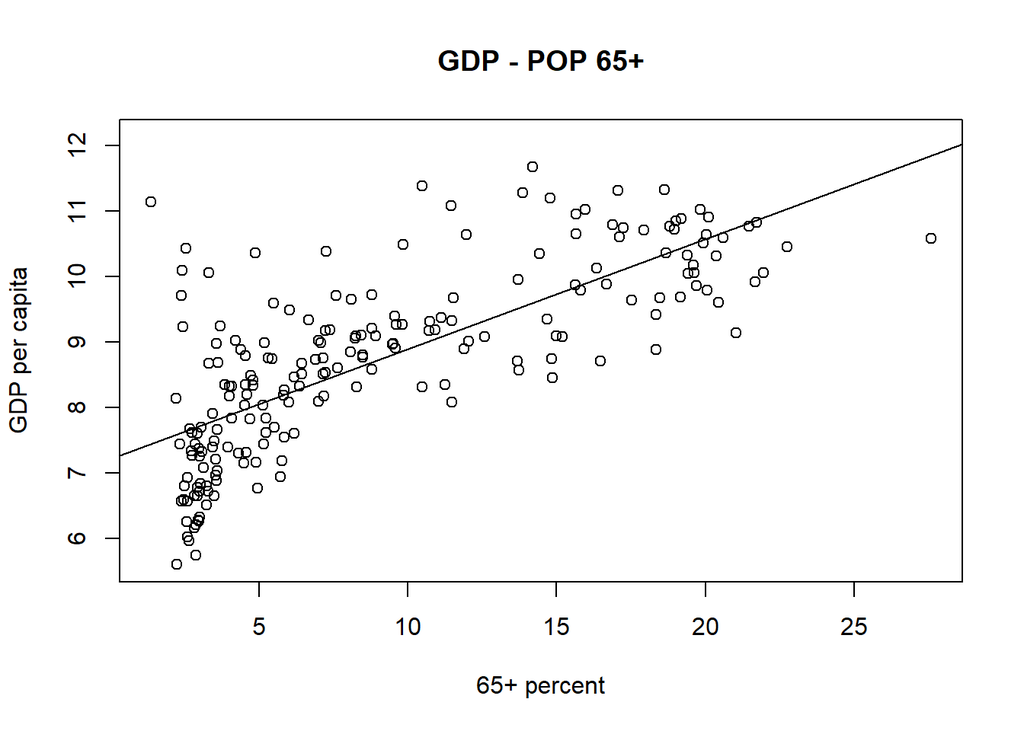

```r
# delete the 10% countries with the lowest GDP per Capita
lowest_GDP <- round(nrow(eco)%*% 0.1,)
eco_plot <- head(eco,-lowest_GDP)

# create the plot of GDP per capita VS pop65
plot(x = suppressWarnings(as.numeric(eco_plot$pop65)), y = log(suppressWarnings(as.numeric(eco_plot$GDP_per_capita))), xlab="65+ percent", ylab="GDP per capita" ,main="GDP - POP 65+")
reg1 <- lm(log(suppressWarnings(as.numeric(eco_plot$GDP_per_capita))) ~ suppressWarnings(as.numeric(eco_plot$pop65)))
abline(reg1)
```

###3.d -One can see a positive relationship between the variables, their correlation is high, but causality cannot yet be inferred.

### Q4

### Joining the Datasets

20 points

1. Join the `deaths.agg`, `cases.agg`, and `recovered.agg` into one data-frame called `corona`.(5pts)
2. Join the `corona` and `eco` data-frames in a way that will keep the most information regarding the data (but not full join). Make sure that no essential data is thrown away (show this). (3pts)
3. Create new columns of normalized `cases`, `deaths`, and `recovered` so they will show the number of cases per 100,000 people for each country.  
   Using the last day of March as a reference, create a single stacked bar plot that visualizes the top 10 countries in terms of normalized Corona cases, and their respected normalized Corona deaths and recovered, as done in Q1.  
   how is it different from the graph before normalization? (5pts)
4. Using the last day of March as a reference, create a scatter-plot of normalized deaths and cases vs. `pop65`. Limit the plot to show only countries with 15% or more of `pop65`.  
   In addition, color the outliers( pop65>24, norm100K_deaths>15) in that plot in red and add to the plot their country names (7pts)

**Solution:**

```r
# a - create 'corona' data-frame
corona <- left_join( cases.agg ,deaths.agg, by= c("Country.Region", "Date"))
corona <- left_join (corona, recovered.agg, by = c("Country.Region", "Date"))

# b
# Find the countries listed in eco and not in corona
names(corona)[names(corona) == "Country.Region"] <- "country"
eco_names <- as.character(eco$country[!eco$country %in% corona$country])
corona_names <- as.character(unique(corona$country))
length(corona_names)==length(eco_names) # not the same number of countries in corona and eco, missing information
```

```
## [1] FALSE
```

```r
# # Change the names of the relevant countries
eco$country<- as.character(eco$country)
eco$country[eco$country=="Myanmar"] <- "Burma"
eco$country[eco$country=="Brunei Darussalam"] <- "Brunei"
eco$country[eco$country=="Bahamas, The"] <- "Bahamas"
eco$country[eco$country=="Congo, Dem. Rep."] <- "Congo (Kinshasa)"
eco$country[eco$country=="Congo, Rep."] <- "Congo (Brazzaville)"
eco$country[eco$country=="Czech Republic"] <- "Czechia"
eco$country[eco$country=="Egypt, Arab Rep."] <- "Egypt"
eco$country[eco$country=="Gambia, The"] <- "Gambia"
eco$country[eco$country=="Iran, Islamic Rep."] <- "Iran"
eco$country[eco$country=="Korea, Rep."] <- "Korea, South"
eco$country[eco$country=="Kyrgyz Republic"] <- "Kyrgyzstan"
eco$country[eco$country=="Lao PDR"] <- "Laos"
eco$country[eco$country=="Russian Federation"] <- "Russia"
eco$country[eco$country=="Slovak Republic"] <- "Slovakia"
eco$country[eco$country=="St. Kitts and Nevis"] <- "Saint Kitts and Nevis"
eco$country[eco$country=="St. Lucia"] <- "Saint Lucia"
eco$country[eco$country=="St. Vincent and the Grenadines"] <- "Saint Vincent and the Grenadines"
eco$country[eco$country=="Sub-Saharan Africa"] <- "Western Sahara"
eco$country[eco$country=="Syrian Arab Republic"] <- "Syria"
eco$country[eco$country=="United States"] <- "US"
eco$country[eco$country=="Venezuela, RB"] <- "Venezuela"
eco$country[eco$country=="Yemen, Rep."] <- "Yemen"

# join eco and corona

corona_eco <- left_join(corona,eco, by = "country" )
# c
# normalized columns Corona cases, deaths and recovered
corona_eco$cases <- c(suppressWarnings((as.numeric(corona_eco$Value.x)/as.numeric(corona_eco$pop_total))) * 100000)
corona_eco$deaths <- c(suppressWarnings((as.numeric(corona_eco$Value.y)/as.numeric(corona_eco$pop_total)))* 100000)
corona_eco$recovered <- c(suppressWarnings((as.numeric(corona_eco$Value)/as.numeric(corona_eco$pop_total))) * 100000)
corona_eco$sick <- c(corona_eco$cases-corona_eco$deaths-corona_eco$recovered)

# new 'corona' data frame for 31.3.2020
corona_eco_march <- corona_eco[which(corona_eco$Date == "2020-03-31"),]
corona_eco1 <- head(corona_eco_march[order(corona_eco_march$cases , decreasing = TRUE),],10)
corona_eco1
```

```
## # A tibble: 10 x 22
## # Groups:   GDP (constant LCU) [9]
##    country Date       Value.x Diff.x Value.y Diff.y Value `GDP (constant ~ GDP
##    <chr>   <date>       <int>  <int>   <int>  <int> <int> <chr>            <chr>
##  1 San Ma~ 2020-03-31     236      6      26      1    13 ..               ..
##  2 Andorra 2020-03-31     376      6      12      4    10 2002840000       3236~
##  3 Luxemb~ 2020-03-31    2178    190      23      1    80 57152595000      7088~
##  4 Iceland 2020-03-31    1135     49       2      0   198 2687785095001.15 2587~
##  5 Spain   2020-03-31   95923   7967    8464    748 19259 1169218000000    1419~
##  6 Switze~ 2020-03-31   16605    683     433     74  1823 696139480200     7051~
##  7 Liecht~ 2020-03-31      68      6       0      0     0 ..               ..
##  8 Italy   2020-03-31  105792   4053   12428    837 15729 1718515200000    2083~
##  9 Monaco  2020-03-31      52      3       1      0     2 5720647180.37038 7184~
## 10 Austria 2020-03-31   10180    562     128     20  1095 368856790000     4552~
## # ... with 13 more variables: `GDP, PPP (current international $)` <chr>,
## #   `Government expenditure on education, total (% of GDP)` <chr>, pop65 <chr>,
## #   pop_city_ratio <chr>, pop_total <chr>, `Unemployment, female (% of female
## #   labor force) (modeled ILO estimate)` <chr>, `Unemployment, male (% of male
## #   labor force) (modeled ILO estimate)` <chr>, `Unemployment, total (% of
## #   total labor force) (modeled ILO estimate)` <chr>, GDP_per_capita <dbl>,
## #   cases <dbl>, deaths <dbl>, recovered <dbl>, sick <dbl>
```

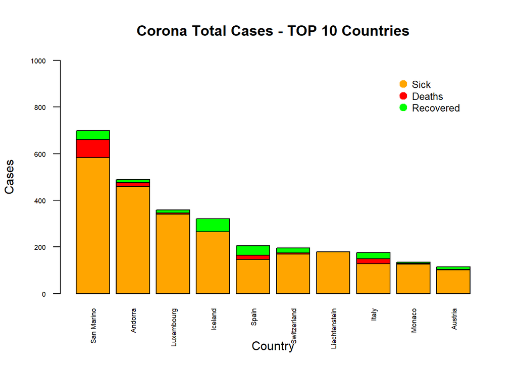

```r
# create new table for the bar plot table with type coloumn =sick/deaths/recovered
barp_table_m <- data.frame(name = rep(c("sick","deaths","recovered"), each = 10), country = rep(corona_eco1$country,3),values = c(corona_eco1$sick, corona_eco1$deaths, corona_eco1$recovered))

# Create visualization variables for the barplot
colors_m = c("orange","red","green")
val_mat_m <- matrix(c(barp_table_m$values),nrow = 3,ncol = 10,byrow = TRUE)
countries_m <- as.vector(corona_eco1$country)
kind_m <- c( "Sick", "Deaths","Recovered")

# create the noramalized bar plot
{barplot(val_mat_m, main = "Corona Total Cases - TOP 10 Countries", names.arg = countries_m ,las = 2, xlab = "Country", ylab = "Cases", cex.axis= 0.55, cex.names = 0.55, col = colors,ylim = c(0,1000))
legend("topright", kind_m , col = colors_m , bty = "n", pch=20 , pt.cex = 2, cex = 0.8, horiz = FALSE, inset = c(0.05, 0.05))}
```

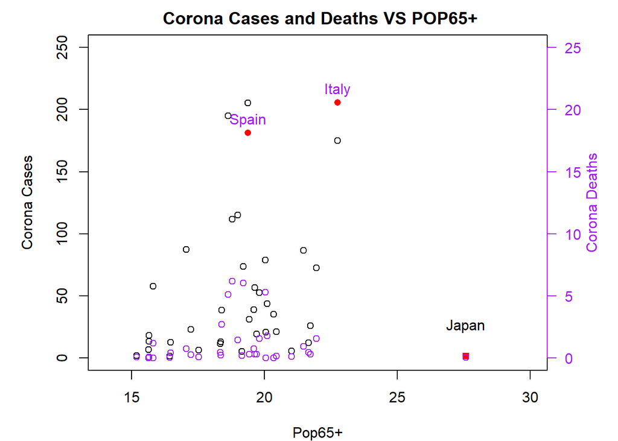

```r
# As we can see, when comparing the normalized values by population in each country,we get different results than regular comparison. Since the new comparison takes into account the size of the population, the results are more accurate and closer to reality.


# d
# filter the countries with 15% or more of `pop65
corona_eco_march <- corona_eco_march[which(suppressWarnings(as.numeric(corona_eco_march$pop65)) >= 15),]
# create variables for points names in the plot
label_cases <- ifelse(as.numeric(corona_eco_march$pop65)> 24, as.character(corona_eco_march$country),"")
label_death <- ifelse(corona_eco_march$deaths > 15, as.character(corona_eco_march$country),"")

# create the unified plot for corona cases and deaths vs pop65+
## cases points in black and deaths in purple
par(mar=c(4,5,2,4))
plot(x = as.numeric(corona_eco_march$pop65), y = as.numeric(corona_eco_march$cases) ,pch = ifelse(as.numeric(corona_eco_march$pop65) > 24 , 15,21),col = ifelse(as.numeric(corona_eco_march$pop65) > 24 ,"red", "black"),main = " Corona Cases and Deaths VS POP65+", xlab = "Pop65+", ylab = "Corona Cases", xlim =  c(14,30), ylim = c(0,250))
par(new = TRUE)
plot(x = as.numeric(corona_eco_march$pop65), y = as.numeric(corona_eco_march$deaths), pch = ifelse((corona_eco_march$deaths) > 15, 16,1),col = ifelse((corona_eco_march$deaths) > 15,"red", "purple"),axes = FALSE,xlab = "",ylab = "",ylim = c(0,25),xlim =  c(14,30))
mtext("Corona Deaths",side=4,col="purple",line=2)
axis(4, ylim=c(0,25), col="purple",col.axis="purple",las=2)
with(corona_eco_march,text(deaths ~ pop65, labels = label_death, pos = 3,col = "purple"))
with(corona_eco_march,text(cases ~ pop65, labels = label_cases, pos = 3))
```

### Q5

### Open Question

10 points

Write an interesting research question regarding the Corona outbreak and then follow the steps to answer it using tables and plots. You can use the loaded datasets or any other dataset you find as long as you add the data file to your `lab1` repository so it can be loaded directly from a `url` (e.g. the World Bank). This question will be graded based on creativity, originality, and the novelty of the analysis.

**Solution:**

```r
cig_data <- read.csv(url("https://apps.who.int/gho/athena/data/GHO/R_Sp_excise_average,R_Ad_val_average,R_imp_duty_average,R_VAT_average,R_Other_average,R_total_tax_average?filter=COUNTRY:*;REGION:*&x-sideaxis=COUNTRY;YEAR&x-topaxis=GHO&profile=crosstable&format=csv"))

# Delete the countries with no taxes information and calculate the rest according to 2014
cig_data <- cig_data[!(cig_data$Average...taxes.as.a...of.cigarette.price...total.tax == "Not available" | cig_data$Average...taxes.as.a...of.cigarette.price...total.tax ==    "Not applicable" ),]
cig_data <- cig_data[cig_data$Year == "2014",]

# Find the countries listed in join_cig and not in eco
cig_names <- as.character(cig_data$Country[!cig_data$Country %in% cases_march$Country.Region])
cig_names
```

```
##  [1] "Bolivia (Plurinational State of)"
##  [2] "Comoros"
##  [3] "Iran (Islamic Republic of)"
##  [4] "Republic of Korea"
##  [5] "Republic of Moldova"
##  [6] "Republic of North Macedonia"
##  [7] "Russian Federation"
##  [8] "United Kingdom of Great Britain and Northern Ireland"
##  [9] "United States of America"
## [10] "Viet Nam"
```

```r
names(cig_data)[names(cig_data)== "Country"] <- "Country.Region"

# Change the name of the relevant countries
cig_data$Country.Region<- as.character(cig_data$Country.Region)
cig_data$Country.Region[cig_data$Country.Region=="Bolivia (Plurinational State of)"] <- "Bolivia"
cig_data$Country.Region[cig_data$Country.Region=="Iran (Islamic Republic of)"] <- "Iran"
cig_data$Country.Region[cig_data$Country.Region=="Republic of Korea"] <- "Korea, South"
cig_data$Country.Region[cig_data$Country.Region=="Republic of Moldova"] <- "Moldova"
cig_data$Country.Region[cig_data$Country.Region=="Russian Federation"] <- "Russia"
cig_data$Country.Region[cig_data$Country.Region=="Republic of North Macedonia"] <- "North Macedonia"
cig_data$Country.Region[cig_data$Country.Region=="United Kingdom of Great Britain and Northern Ireland"] <- "Ireland"
cig_data$Country.Region[cig_data$Country.Region=="United States of America"] <- "US"
cig_data$Country.Region[cig_data$Country.Region=="Viet Nam"] <- "Vietnam"
cig_data <- cig_data[-which(cig_data$Country.Region == "Comoros"),]
# Merge the data with the corona cases on 31.3.20 data-frame
join_cig <- left_join(cig_data, cases_march ,by="Country.Region")
```

```r
# Convert data from numbers to percent
names(join_cig)[names(join_cig)== "Average...taxes.as.a...of.cigarette.price...total.tax"] <- "total_tax"
join_cig$total_tax <- as.character(join_cig$total_tax)
class(join_cig$total_tax) <- "double"

# Merge the data with the eco data frame
cig_names <- as.character(join_cig$Country.Region[!join_cig$Country.Region %in% eco$country])
names(join_cig)[names(join_cig)== "Country.Region"] <- "country"
join_cig <- left_join(join_cig, eco, by = "country")

# Create a normalized column of corona cases per country
join_cig$normal_pop <- c((as.numeric(join_cig$Value) / as.numeric(join_cig$pop_total)*10))


# Creates a graph that examines the connection between cig.taxes and the corona cases number in each country
cor(join_cig$total_tax, join_cig$normal_pop)
```

```
## [1] 0.2689314
```

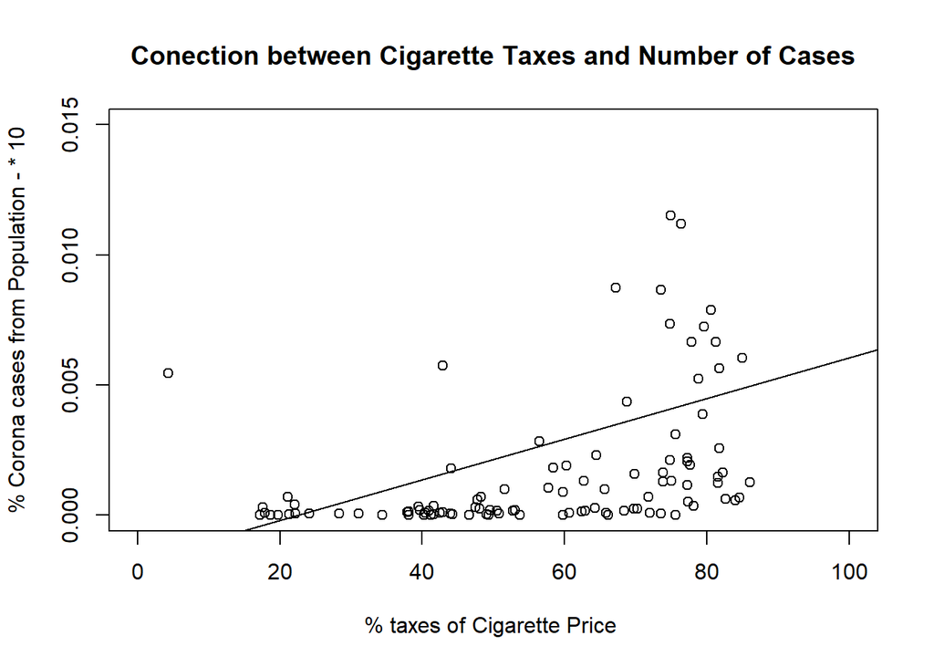

```r
plot(x =as.numeric(join_cig$total_tax), y = as.numeric(join_cig$normal_pop),xlim = c(0,100), ylim = c(0,0.015) ,xlab="% taxes of Cigarette Price ", ylab="% Corona cases from Population - * 10" ,main="Conection between Cigarette Taxes and Number of Cases")
reg5 <- lm(as.numeric(join_cig$normal_pop) ~ as.numeric(join_cig$total_tax))
abline(reg5)
```

```r
cor(join_cig$total_tax, join_cig$normal_pop)
```

```
## [1] 0.2689314
```